# for() loops

Robert Cope

10/08/2020

## Motivation

Often, you wish to run the same R code many times. For example, you might want to perform a simulation experiment many times, or run some complex analysis on each row of a dataset. To do this, you use a programming paradigm called a loop. Loops are common to most programming languages, including R. The simplest loop is a `for()` loop.

## Simple example

In a for loop, you define some variable (in this case, `i`), and a vector of the values it will take in your loop (in this case, `seq(1,10)`, i.e., numbers 1, 2, 3, …, 10). Then you have a set of curly braces `{}`, and inside the curly braces is the code that will run at each step of the loop. In the below, we just print `i`.

```r
for(i in seq(1,10)){
  print(i)
}
```

```
## [1] 1
## [1] 2
## [1] 3
## [1] 4
## [1] 5
## [1] 6
## [1] 7
## [1] 8
## [1] 9
## [1] 10
```

(i and j are very common choices of variable in a for loop; being consistent in this way can help make your code easier to read both for yourself and others)

## A complex example

Imagine you did an experiment and observed the following data

```r
library(tidyverse)
ex_df <- tibble(x = c(0.331063021956931,-0.235467710788757,-2.09431603312214,
                                 0.187056090792243,0.0191990692214917,
                                 -0.215373899894128,0.291563982825806,2.03381447923879,
                                 -0.196097283153727,0.340690828562206))

ex_df %>%
  summarise(mean(x), sd(x))
```

```
## # A tibble: 1 x 2
##   `mean(x)` `sd(x)`
##       <dbl>   <dbl>
## 1    0.0462   0.999
```

```r
ex_df %>% arrange(x)
```

```
## # A tibble: 10 x 1
##          x
##      <dbl>
##  1 -2.09
##  2 -0.235
##  3 -0.215
##  4 -0.196
##  5  0.0192
##  6  0.187
##  7  0.292
##  8  0.331
##  9  0.341
## 10  2.03
```

The data have mean approximately 0 and standard deviation approximately 1, but I notice that two of the values are quite extreme – moreso than I would expect.

I would like to know how weird this is. More specifically, if I generate 10 numbers from a normal disribution with mean 0 and standard deviation 1, how often would I expect two of them to have absolute value > 2? (i.e., be > 2 or < -2)

I could calculate this mathematically if necessary, but a simulation experiment is probably quicker and more intuitive.

First, we will set up a tibble to store the experiment results:

```r
experiment_df <- tibble(experiment_index = seq(1, 10000), second_biggest = NA)
```

Then, we use a for() loop to do the experiment. At each iteration of the loop, we generate 10 random numbers, extract the one with the second biggest magnitude, and then store it in our tibble.

```r
for(i in seq(1,nrow(experiment_df))){

  #generate the 10 random numbers
  sim_df <- tibble(x = rnorm(10,mean = 0, sd = 1))

  #extract the second biggest one
  second_biggest <- (sim_df %>%
                       mutate(abs_x = abs(x)) %>%
                       arrange(desc(abs_x)) %>%
                       slice(2) %>% #slice(2) gives the second row
                       pull())  #pull turns it into a vector

  #then we store it in the tibble we created earlier
  experiment_df$second_biggest[i] <- second_biggest
}

head(experiment_df)
```

```
## # A tibble: 6 x 2
##   experiment_index second_biggest
##              <int>          <dbl>
## 1                1          0.803
## 2                2          1.30
## 3                3          2.51
## 4                4          1.41
## 5                5          1.41
## 6                6          1.46
```

Now we can plot the results.

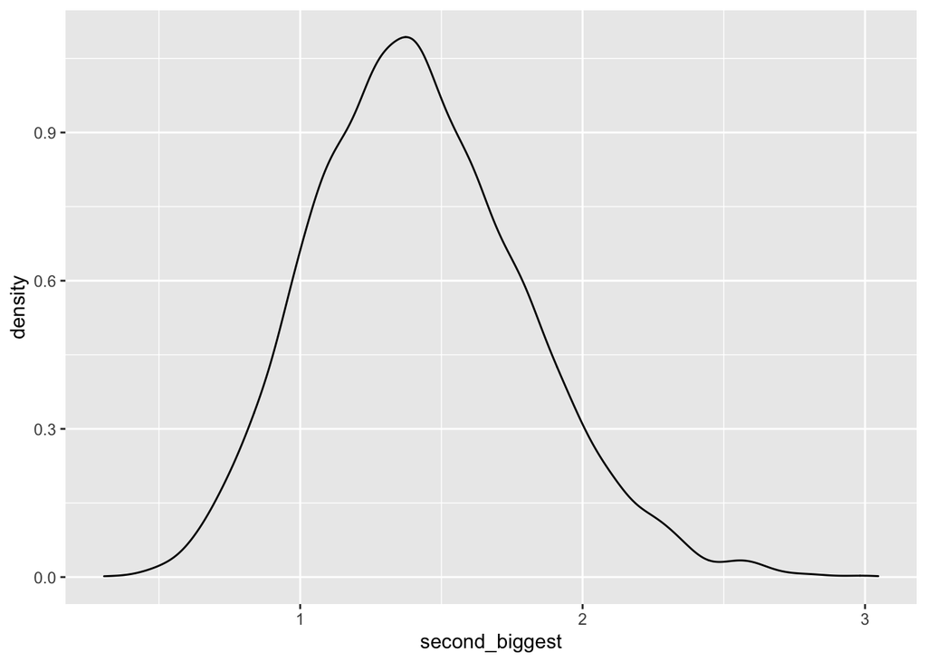

```r
ggplot(experiment_df,aes(x=second_biggest))+
  geom_density()
```

And count how many times the second biggest value is at least 2:

```r
experiment_df %>%
  mutate(greater_than_2 = ifelse(second_biggest > 2, 'yes', 'no')) %>%
  group_by(greater_than_2) %>%
  summarise(count = n())
```

```
## # A tibble: 2 x 2
##   greater_than_2 count
##   <chr>          <int>
## 1 no              9283
## 2 yes              717
```

So of our 10000 trials, around 7% had the second largest magnitude of at least 2 – which suggests to me that it is somewhat rare but not inconceivable.

Side note: Do you think that this simulation experiment is actually fair? Does it quantify how weird the data we observed actually are?